# Create an efficient random number generator

# Build the code training loop

```python
def run_eval(model, eval_data):
    """
    Scores the model on the evaluation data and returns the F1
    """
    model.eval()  # Set model to evaluation mode
    true_labels = []
    predictions = []

    with torch.no_grad():
        for word_ids, label in eval_data:
            # Check if word_ids is already a tensor
            if not isinstance(word_ids, torch.Tensor):
                word_ids = torch.tensor([word_ids], dtype=torch.long)

            # Forward pass
            pred, _ = model(word_ids)

            # Convert to binary prediction (0 or 1)
            binary_pred = (pred > 0.5).float()

            # Store true label and prediction
            if isinstance(label, torch.Tensor):
                true_labels.append(label.item())
            else:
                true_labels.append(label[0])

            predictions.append(binary_pred.item())

    f1 = f1_score(np.array(true_labels), np.array(predictions))

    return f1
```

```python
# Initialize model
vocab_size = len(word_to_index)
embedding_size = 100
num_heads = 4
model = DocumentAttentionClassifier(
    vocab_size, embedding_size, num_heads, "word2vec_embeddings.pt"
)

# Initialize loss and optimizer
criterion = nn.BCELoss()
optimizer = optim.AdamW(model.parameters(), lr=5e-5)


class SentimentDataset(Dataset):
    def __init__(self, data_list):
        self.data = data_list

    def __len__(self):
        return len(self.data)

    def __getitem__(self, idx):
        word_ids, label = self.data[idx]
        return word_ids, label


# Create datasets and dataloaders
train_dataset = SentimentDataset(train_list)
dev_dataset = SentimentDataset(dev_list)


# Use a custom collate function to handle variable-length sequences
def collate_fn(batch):
    word_ids, labels = batch[0]
    return torch.tensor([word_ids]), torch.tensor([labels])


train_loader = DataLoader(
    train_dataset, batch_size=1, shuffle=True, collate_fn=collate_fn
)
dev_loader = DataLoader(dev_dataset, batch_size=1, shuffle=False, collate_fn=collate_fn)

# Initialize weights and biases (wandb) here
wandb.init(project="document-attention-classifier")
wandb.config.update(
    {
        "learning_rate": 5e-5,
        "epochs": 1,
        "batch_size": 1,
        "embedding_size": embedding_size,
        "num_heads": num_heads,
    }
)

for epoch in range(1):
    model.train()
    loss_sum = 0
    epoch_progress = tqdm(total=len(train_loader), desc=f"Epoch {epoch + 1}")

    for step, data in enumerate(train_loader):
        word_ids, label = data

        # Zero the parameter gradients
        optimizer.zero_grad()

        # Forward pass
        predictions, _ = model(word_ids)

        # Compute loss
        loss = criterion(predictions, label)

        # Backward pass and optimize
        loss.backward()
        optimizer.step()

        # Accumulate loss
        loss_sum += loss.item()

        # Report loss every 500 steps to wandb and reset sum
        if (step + 1) % 500 == 0:
            avg_loss = loss_sum / 500
            wandb.log({"loss": avg_loss}, step=step)
            print(f"Step {step + 1}, Loss: {avg_loss:.4f}")
            loss_sum = 0

        # Evaluate on dev set every 5000 steps and report to wandb
        if (step + 1) % 5000 == 0:
            model.eval()
            with torch.no_grad():
                true_labels = []
                predictions = []

                for dev_word_ids, dev_label in dev_loader:
                    pred, _ = model(dev_word_ids)
                    binary_pred = (pred > 0.5).float()

                    true_labels.append(dev_label.item())
                    predictions.append(binary_pred.item())

                f1 = f1_score(true_labels, predictions)

                wandb.log({"dev_f1": f1}, step=step)
                print(f"Step {step + 1}, Dev F1: {f1:.4f}")

            # Switch back to training mode
            model.train()

        # Update progress bar
        epoch_progress.update(1)

# Once you finish training, it's good practice to switch to eval.
model.eval()
```

Tracking run with wandb version 0.19.7

Run data is saved locally in `/Users/anupamabhatta/Desktop/u-m/SI 630/Homework 2/wandb/run-20250227_135947-2k41idkk`

Syncing run **[vibrant-capybara-2](https://wandb.ai/axbhatta-university-of-michigan/document-attention-classifier/runs/2k41idkk)** to [Weights & Biases](https://wandb.ai/axbhatta-university-of-michigan/document-attention-classifier) ([docs](https://wandb.me/developer-guide))

View project at https://wandb.ai/axbhatta-university-of-michigan/document-attention-classifier

View run at https://wandb.ai/axbhatta-university-of-michigan/document-attention-classifier/runs/2k41idkk

```
  return torch.tensor([word_ids]), torch.tensor([labels])
```

```
Step 500, Loss: 0.6921
```

```
Step 1000, Loss: 0.6898
```

```
Step 1500, Loss: 0.6871
```

```
Step 2000, Loss: 0.6852
```

```
Step 2500, Loss: 0.6817
```

```
Step 3000, Loss: 0.6779
```

```
Step 3500, Loss: 0.6734
```

```
Step 4000, Loss: 0.6684
```

```
Step 4500, Loss: 0.6616
```

```
Step 5000, Loss: 0.6564
```

```
Step 5000, Dev F1: 0.8243
```

```
Step 5500, Loss: 0.6479
```

```
Step 6000, Loss: 0.6431
```

```
Step 6500, Loss: 0.6325
```

```
Step 7000, Loss: 0.6214
```

```
Step 7500, Loss: 0.6072
```

```
Step 8000, Loss: 0.6053
```

```
Step 8500, Loss: 0.5829
```

```
Step 9000, Loss: 0.5746
```

```
Step 9500, Loss: 0.5486
```

```
Step 10000, Loss: 0.5542
```

```
Step 10000, Dev F1: 0.8333
```

```
Step 10500, Loss: 0.5469
```

```
Step 11000, Loss: 0.5351
```

```
Step 11500, Loss: 0.5034
```

```
Step 12000, Loss: 0.4908
```

```
Step 12500, Loss: 0.4688
```

```
Step 13000, Loss: 0.4591
```

```
Step 13500, Loss: 0.4772
```

```
Step 14000, Loss: 0.4331
```

```
Step 14500, Loss: 0.4309
```

```
Step 15000, Loss: 0.4281
```

```
Step 15000, Dev F1: 0.8407
```

```
Step 15500, Loss: 0.3911
```

```
Step 16000, Loss: 0.4355
```

```
Step 16500, Loss: 0.3630
```

```
Step 17000, Loss: 0.4062
```

```
Step 17500, Loss: 0.3845
```

```
Step 18000, Loss: 0.3611
```

```
Step 18500, Loss: 0.3802
```

```
Step 19000, Loss: 0.3633
```

```
Step 19500, Loss: 0.3534
```

```
Step 20000, Loss: 0.3664
```

```
Step 20000, Dev F1: 0.8483
```

```
Step 20500, Loss: 0.3689
```

```
Step 21000, Loss: 0.3732
```

```
Step 21500, Loss: 0.3621
```

```
Step 22000, Loss: 0.3544
```

```
Step 22500, Loss: 0.3613
```

```
Step 23000, Loss: 0.3482
```

```
Step 23500, Loss: 0.3552
```

```
Step 24000, Loss: 0.3483
```

```
Step 24500, Loss: 0.3369
```

```
Step 25000, Loss: 0.3018
```

```
Step 25000, Dev F1: 0.8574
```

```
Step 25500, Loss: 0.3188
```

```
Step 26000, Loss: 0.3387
```

```
Step 26500, Loss: 0.3337
```

```
Step 27000, Loss: 0.3269
```

```
Step 27500, Loss: 0.3158
```

```
Step 28000, Loss: 0.3471
```

```
Step 28500, Loss: 0.3420
```

```
Step 29000, Loss: 0.3111
```

```
Step 29500, Loss: 0.3469
```

```
Step 30000, Loss: 0.3465
```

```
Step 30000, Dev F1: 0.8627
```

```
Step 30500, Loss: 0.3323
```

```
Step 31000, Loss: 0.3177
```

```
Step 31500, Loss: 0.3185
```

```
Step 32000, Loss: 0.3171
```

```
Step 32500, Loss: 0.2822
```

```
Step 33000, Loss: 0.3456
```

```
Step 33500, Loss: 0.4053
```

```
Step 34000, Loss: 0.3685
```

```
Step 34500, Loss: 0.3482
```

```
Step 35000, Loss: 0.3334
```

```
Step 35000, Dev F1: 0.8681
```

```
Step 35500, Loss: 0.3608
```

```
Step 36000, Loss: 0.3060
```

```
Step 36500, Loss: 0.2875
```

```
Step 37000, Loss: 0.3032
```

```
Step 37500, Loss: 0.2921
```

```
Step 38000, Loss: 0.3355
```

```
Step 38500, Loss: 0.2707
```

```
Step 39000, Loss: 0.3267
```

```
Step 39500, Loss: 0.3121
```

```
Step 40000, Loss: 0.3055
```

```
Step 40000, Dev F1: 0.8752
```

```
Step 40500, Loss: 0.3048
```

```
Step 41000, Loss: 0.3096
```

```
Step 41500, Loss: 0.2766
```

```
Step 42000, Loss: 0.3340
```

```
Step 42500, Loss: 0.2876
```

```
Step 43000, Loss: 0.2925
```

```
Step 43500, Loss: 0.3181
```

```
Step 44000, Loss: 0.2627
```

```
Step 44500, Loss: 0.2749
```

```
Step 45000, Loss: 0.2895
```

```
Step 45000, Dev F1: 0.8791
```

```
Step 45500, Loss: 0.2612
```

```
Step 46000, Loss: 0.2944
```

```
Step 46500, Loss: 0.2761
```

```
Step 47000, Loss: 0.3190
```

```
Step 47500, Loss: 0.3297
```

```
Step 48000, Loss: 0.3242
```

```
Step 48500, Loss: 0.2697
```

```
Step 49000, Loss: 0.3353
```

```
Step 49500, Loss: 0.3013
```

```
Step 50000, Loss: 0.3102
```

```
Step 50000, Dev F1: 0.8789
```

```
Step 50500, Loss: 0.3176
```

```
Step 51000, Loss: 0.3536
```

```
Step 51500, Loss: 0.3313
```

```
Step 52000, Loss: 0.2839
```

```
Step 52500, Loss: 0.2779
```

```
Step 53000, Loss: 0.2562
```

```
Step 53500, Loss: 0.3118
```

```
Step 54000, Loss: 0.3484
```

```
Step 54500, Loss: 0.3167
```

```
Step 55000, Loss: 0.3067
```

```
Step 55000, Dev F1: 0.8827
```

```
Step 55500, Loss: 0.2672
```

```
Step 56000, Loss: 0.3070
```

```
Step 56500, Loss: 0.3079
```

```
Step 57000, Loss: 0.2910
```

```
Step 57500, Loss: 0.3043
```

```
Step 58000, Loss: 0.2722
```

```
Step 58500, Loss: 0.3296
```

```
Step 59000, Loss: 0.2841
```

```
Step 59500, Loss: 0.2804
```

```
Step 60000, Loss: 0.3145
```

```
Step 60000, Dev F1: 0.8841
```

```
Step 60500, Loss: 0.3068
```

```
Step 61000, Loss: 0.3163
```

```
Step 61500, Loss: 0.3130
```

```
Step 62000, Loss: 0.2953
```

```
Step 62500, Loss: 0.2900
```

```
Step 63000, Loss: 0.2767
```

```
Step 63500, Loss: 0.2967
```

```
Step 64000, Loss: 0.3014
```

```
Step 64500, Loss: 0.2955
```

```
Step 65000, Loss: 0.3312
```

```
Step 65000, Dev F1: 0.8848
```

```
Step 65500, Loss: 0.3039
```

```
Step 66000, Loss: 0.2929
```

```
Step 66500, Loss: 0.2785
```

```
Step 67000, Loss: 0.2786
```

```
Step 67500, Loss: 0.3156
```

```
Step 68000, Loss: 0.2679
```

```
Step 68500, Loss: 0.3088
```

```
Step 69000, Loss: 0.2617
```

```
Step 69500, Loss: 0.3014
```

```
Step 70000, Loss: 0.3228
```

```
Step 70000, Dev F1: 0.8856
```

```
Step 70500, Loss: 0.2316
```

```
Step 71000, Loss: 0.2857
```

```
Step 71500, Loss: 0.3214
```

```
Step 72000, Loss: 0.3134
```

```
Step 72500, Loss: 0.3159
```

```
Step 73000, Loss: 0.2524
```

```
Step 73500, Loss: 0.3072
```

```
Step 74000, Loss: 0.3062
```

```
Step 74500, Loss: 0.2953
```

```
Step 75000, Loss: 0.2909
```

```
Step 75000, Dev F1: 0.8888
```

```
Step 75500, Loss: 0.3181
```

```
Step 76000, Loss: 0.3074
```

```
Step 76500, Loss: 0.2757
```

```
Step 77000, Loss: 0.2689
```

```
Step 77500, Loss: 0.2858
```

```
Step 78000, Loss: 0.3169
```

```
Step 78500, Loss: 0.3045
```

```
Step 79000, Loss: 0.2815
```

```
Step 79500, Loss: 0.2811
```

```
Step 80000, Loss: 0.2767
```

```
Step 80000, Dev F1: 0.8905
```

```
Step 80500, Loss: 0.2393
```

```
Step 81000, Loss: 0.2229
```

```
Step 81500, Loss: 0.2926
```

```
Step 82000, Loss: 0.2640
```

```
Step 82500, Loss: 0.2894
```

```
Step 83000, Loss: 0.2900
```

```
Step 83500, Loss: 0.2939
```

```
Step 84000, Loss: 0.3043
```

```
Step 84500, Loss: 0.2702
```

```
Step 85000, Loss: 0.2531
```

```
Step 85000, Dev F1: 0.8905
```

```
Step 85500, Loss: 0.2678
```

```
Step 86000, Loss: 0.2802
```

```
Step 86500, Loss: 0.2734
```

```
Step 87000, Loss: 0.3165
```

```
Step 87500, Loss: 0.2953
```

```
Step 88000, Loss: 0.2635
```

```
Step 88500, Loss: 0.3391
```

```
Step 89000, Loss: 0.3525
```

```
Step 89500, Loss: 0.2407
```

```
Step 90000, Loss: 0.2277
```

```
Step 90000, Dev F1: 0.8905
```

```
Step 90500, Loss: 0.2899
```

```
Step 91000, Loss: 0.2337
```

```
Step 91500, Loss: 0.2339
```

```
Step 92000, Loss: 0.2906
```

```
Step 92500, Loss: 0.2634
```

```
Step 93000, Loss: 0.2658
```

```
Step 93500, Loss: 0.3282
```

```
Step 94000, Loss: 0.3184
```

```
Step 94500, Loss: 0.2902
```

```
Step 95000, Loss: 0.3096
```

```
Step 95000, Dev F1: 0.8909
```

```
Step 95500, Loss: 0.2859
```

```
Step 96000, Loss: 0.2761
```

```
Step 96500, Loss: 0.2448
```

```
Step 97000, Loss: 0.2562
```

```
Step 97500, Loss: 0.2664
```

```
Step 98000, Loss: 0.2719
```

```
Step 98500, Loss: 0.2833
```

```
Step 99000, Loss: 0.3048
```

```
Step 99500, Loss: 0.2593
```

```
Step 100000, Loss: 0.2736
```

```
Step 100000, Dev F1: 0.8913
```

```
Step 100500, Loss: 0.2997
```

```
Step 101000, Loss: 0.2324
```

```
Step 101500, Loss: 0.2554
```

```
Step 102000, Loss: 0.2545
```

```
Step 102500, Loss: 0.3133
```

```
Step 103000, Loss: 0.2701
```

```
Step 103500, Loss: 0.2770
```

```
Step 104000, Loss: 0.2920
```

```
Step 104500, Loss: 0.2987
```

```
Step 105000, Loss: 0.2777
```

```
Step 105000, Dev F1: 0.8921
```

```
Step 105500, Loss: 0.2350
```

```
Step 106000, Loss: 0.2743
```

```
Step 106500, Loss: 0.3114
```

```
Step 107000, Loss: 0.2630
```

```
Step 107500, Loss: 0.2682
```

```
Step 108000, Loss: 0.3074
```

```
Step 108500, Loss: 0.2940
```

```
Step 109000, Loss: 0.2579
```

```
Step 109500, Loss: 0.2849
```

```
Step 110000, Loss: 0.2494
```

```
Step 110000, Dev F1: 0.8920
```

```
Step 110500, Loss: 0.2680
```

```
Step 111000, Loss: 0.3170
```

```
Step 111500, Loss: 0.2789
```

```
Step 112000, Loss: 0.3192
```

```
Step 112500, Loss: 0.3038
```

```
Step 113000, Loss: 0.2327
```

```
Step 113500, Loss: 0.2473
```

```
Step 114000, Loss: 0.2806
```

```
Step 114500, Loss: 0.2793
```

```
Step 115000, Loss: 0.2840
```

```
Step 115000, Dev F1: 0.8924
```

```
Step 115500, Loss: 0.2535
```

```
Step 116000, Loss: 0.2982
```

```
Step 116500, Loss: 0.2860
```

```
Step 117000, Loss: 0.2641
```

```
Step 117500, Loss: 0.2997
```

```
Step 118000, Loss: 0.2753
```

```
Step 118500, Loss: 0.2654
```

```
Step 119000, Loss: 0.3432
```

```
Step 119500, Loss: 0.3172
```

```
Step 120000, Loss: 0.2728
```

```
Step 120000, Dev F1: 0.8931
```

```
Step 120500, Loss: 0.2860
```

```
Step 121000, Loss: 0.2400
```

```
Step 121500, Loss: 0.2978
```

```
Step 122000, Loss: 0.2588
```

```
Step 122500, Loss: 0.2794
```

```
Step 123000, Loss: 0.2710
```

```
Step 123500, Loss: 0.2679
```

```
Step 124000, Loss: 0.2362
```

```
Step 124500, Loss: 0.2973
```

```
Step 125000, Loss: 0.3090
```

```
Step 125000, Dev F1: 0.8928
```

```
Step 125500, Loss: 0.2676
```

```
Step 126000, Loss: 0.2926
```

```
Step 126500, Loss: 0.2817
```

```
Step 127000, Loss: 0.3160
```

```
Step 127500, Loss: 0.2478
```

```
Step 128000, Loss: 0.2343
```

```
Step 128500, Loss: 0.2370
```

```
Step 129000, Loss: 0.2290
```

```
Step 129500, Loss: 0.2807
```

```
Step 130000, Loss: 0.2164
```

```
Step 130000, Dev F1: 0.8933
```

```
Step 130500, Loss: 0.2956
```

```
Step 131000, Loss: 0.2621
```

```
Step 131500, Loss: 0.2443
```

```
Step 132000, Loss: 0.2637
```

```
Step 132500, Loss: 0.2794
```

```
Step 133000, Loss: 0.2462
```

```
Step 133500, Loss: 0.2354
```

```
Step 134000, Loss: 0.2907
```

```
Step 134500, Loss: 0.2708
```

```
Step 135000, Loss: 0.2362
```

```
Step 135000, Dev F1: 0.8921
```

```
Step 135500, Loss: 0.2617
```

```
Step 136000, Loss: 0.2919
```

```
Step 136500, Loss: 0.2464
```

```
Step 137000, Loss: 0.2947
```

```
Step 137500, Loss: 0.2596
```

```
Step 138000, Loss: 0.3163
```

```
Step 138500, Loss: 0.2674
```

```
Step 139000, Loss: 0.2413
```

```
Step 139500, Loss: 0.2875
```

```
Step 140000, Loss: 0.2284
```

```
Step 140000, Dev F1: 0.8936
```

```
Step 140500, Loss: 0.2691
```

```
Step 141000, Loss: 0.2746
```

```
Step 141500, Loss: 0.2357
```

```
Step 142000, Loss: 0.2390
```

```
Step 142500, Loss: 0.2432
```

```
Step 143000, Loss: 0.2893
```

```
Step 143500, Loss: 0.2326
```

```
Step 144000, Loss: 0.2569
```

```
Step 144500, Loss: 0.2451
```

```
Step 145000, Loss: 0.2172
```

```
Step 145000, Dev F1: 0.8930
```

```
Step 145500, Loss: 0.2879
```

```
Step 146000, Loss: 0.2955
```

```
Step 146500, Loss: 0.2444
```

```
Step 147000, Loss: 0.2643
```

```
Step 147500, Loss: 0.2718
```

```
Step 148000, Loss: 0.2942
```

```
Step 148500, Loss: 0.2429
```

```
Step 149000, Loss: 0.2738
```

```
Step 149500, Loss: 0.2696
```

```
Step 150000, Loss: 0.3045
```

```
Step 150000, Dev F1: 0.8937
```

```
Step 150500, Loss: 0.2448
```

```
Step 151000, Loss: 0.3055
```

```
Step 151500, Loss: 0.2908
```

```
Step 152000, Loss: 0.3363
```

```
Step 152500, Loss: 0.2370
```

```
Step 153000, Loss: 0.2786
```

```
Step 153500, Loss: 0.2709
```

```
Step 154000, Loss: 0.2678
```

```
Step 154500, Loss: 0.2661
```

```
Step 155000, Loss: 0.2541
```

```
Step 155000, Dev F1: 0.8948
```

```
Step 155500, Loss: 0.2797
```

```
Step 156000, Loss: 0.2548
```

```
Step 156500, Loss: 0.2501
```

```
Step 157000, Loss: 0.2740
```

```
Step 157500, Loss: 0.2802
```

```
Step 158000, Loss: 0.2612
```

```
Step 158500, Loss: 0.2619
```

```
Step 159000, Loss: 0.2899
```

```
Step 159500, Loss: 0.3472
```

```
Step 160000, Loss: 0.2839
Step 160000, Dev F1: 0.8935
```

```
DocumentAttentionClassifier(
  (embedding): Embedding(52081, 100)
  (output_layer): Linear(in_features=400, out_features=1, bias=True)
)
```

[output not shown]

[output cut: 334 more lines]

#### **Training Parameters Insights**

The model training configuration strikes a balance between performance and computational efficiency. Using a small batch size of 1 with the AdamW optimizer allows for precise parameter updates at each step, while the modest learning rate of 5e-5 prevents overshooting optimal weights. This cautious approach paid dividends, achieving an impressive dev F1 score of 0.8935 after just one epoch, indicating the model quickly learned to distinguish sentiment patterns without requiring extensive training iterations.

```python
# NOTE: This is a duplicate of the run_eval() function defined earlier
# It's repeated here for convenience in a Jupyter notebook environment
# to make this cell self-contained when running the frozen embeddings experiment
def run_eval(model, eval_data):
    """
    Scores the model on the evaluation data and returns the F1
    """
    model.eval()  # Set model to evaluation mode
    true_labels = []
    predictions = []

    with torch.no_grad():
        for word_ids, label in eval_data:
            # Check if word_ids is already a tensor
            if not isinstance(word_ids, torch.Tensor):
                word_ids = torch.tensor([word_ids], dtype=torch.long)

            # Forward pass
            pred, _ = model(word_ids)

            # Convert to binary prediction (0 or 1)
            binary_pred = (pred > 0.5).float()

            # Store true label and prediction
            if isinstance(label, torch.Tensor):
                true_labels.append(label.item())
            else:
                true_labels.append(label[0])

            predictions.append(binary_pred.item())

    f1 = f1_score(np.array(true_labels), np.array(predictions))

    return f1
```

```python
# Create a new model with the same architecture
model_frozen = DocumentAttentionClassifier(
    vocab_size, embedding_size, num_heads, "word2vec_embeddings.pt"
)

# Freeze the embedding layer parameters
for param in model_frozen.embedding.parameters():
    param.requires_grad = False

# Verify embeddings are frozen
embedding_params = sum(
    p.numel() for p in model_frozen.embedding.parameters() if p.requires_grad
)
print(f"Trainable embedding parameters: {embedding_params}")
total_params = sum(p.numel() for p in model_frozen.parameters() if p.requires_grad)
print(f"Total trainable parameters: {total_params}")

# Initialize wandb for tracking the frozen model
wandb.init(project="document-attention-classifier", name="frozen-embeddings-run")

# Set up training components
criterion = nn.BCELoss()
optimizer = optim.AdamW(model_frozen.parameters(), lr=5e-5)

# Training loop for frozen embeddings model
model_frozen.train()
loss_sum = 0
step = 0
start_time = time.time()

progress_bar = tqdm(total=len(train_loader), desc="Training with frozen embeddings")

for word_ids, label in train_loader:
    # Convert to tensors if needed
    word_ids_tensor = (
        word_ids if isinstance(word_ids, torch.Tensor) else torch.tensor(word_ids)
    )
    label_tensor = label if isinstance(label, torch.Tensor) else torch.tensor(label)

    # Zero the parameter gradients
    optimizer.zero_grad()

    # Forward pass
    predictions, _ = model_frozen(word_ids_tensor)

    # Compute loss
    loss = criterion(predictions, label_tensor)

    # Backward pass and optimize
    loss.backward()
    optimizer.step()

    # Track statistics
    loss_sum += loss.item()
    step += 1

    # Report loss every 500 steps
    if step % 500 == 0:
        avg_loss = loss_sum / 500
        print(f"Step {step}, Loss: {avg_loss:.4f}")
        wandb.log({"frozen_loss": avg_loss}, step=step)
        loss_sum = 0

    # Evaluate on dev set every 5000 steps
    if step % 5000 == 0:
        f1 = run_eval(model_frozen, dev_loader)
        print(f"Step {step}, Dev F1: {f1:.4f}")
        wandb.log({"frozen_dev_f1": f1}, step=step)
        model_frozen.train()  # Return to training mode

    # Update progress bar
    progress_bar.update(1)

    # Optional: Break early for testing
    # if step >= 10000:
    #     break

# Calculate total training time
training_time = time.time() - start_time
print(f"Training completed in {training_time:.2f} seconds")

# Final evaluation
final_f1 = run_eval(model_frozen, dev_loader)
print(f"Final Dev F1 (Frozen): {final_f1:.4f}")
wandb.log({"final_frozen_dev_f1": final_f1})

# Close wandb
wandb.finish()

# Save the trained model with frozen embeddings
torch.save(model_frozen.state_dict(), "frozen_attention_classifier.pt")
```

```
Trainable embedding parameters: 0
Total trainable parameters: 801
```

```
Step 500, Loss: 0.6922
```

```
Step 1000, Loss: 0.6907
```

```
Step 1500, Loss: 0.6894
Step 2000, Loss: 0.6872
```

```
Step 2500, Loss: 0.6862
```

```
Step 3000, Loss: 0.6848
```

```
Step 3500, Loss: 0.6824
```

```
Step 4000, Loss: 0.6812
```

```
Step 4500, Loss: 0.6808
```

```
Step 5000, Loss: 0.6803
```

```
Step 5000, Dev F1: 0.8204
Step 5500, Loss: 0.6781
```

```
Step 6000, Loss: 0.6751
Step 6500, Loss: 0.6727
```

```
Step 7000, Loss: 0.6729
Step 7500, Loss: 0.6709
```

```
Step 8000, Loss: 0.6727
Step 8500, Loss: 0.6699
```

```
Step 9000, Loss: 0.6676
Step 9500, Loss: 0.6681
Step 10000, Loss: 0.6649
```

```
Step 10000, Dev F1: 0.8087
Step 10500, Loss: 0.6639
```

```
Step 11000, Loss: 0.6648
Step 11500, Loss: 0.6641
```

```
Step 12000, Loss: 0.6608
Step 12500, Loss: 0.6558
```

```
Step 13000, Loss: 0.6572
```

```
Step 13500, Loss: 0.6527
Step 14000, Loss: 0.6549
```

```
Step 14500, Loss: 0.6528
Step 15000, Loss: 0.6438
```

```
Step 15000, Dev F1: 0.8234
Step 15500, Loss: 0.6518
```

```
Step 16000, Loss: 0.6519
Step 16500, Loss: 0.6439
```

```
Step 17000, Loss: 0.6454
Step 17500, Loss: 0.6428
```

```
Step 18000, Loss: 0.6388
Step 18500, Loss: 0.6384
```

```
Step 19000, Loss: 0.6417
Step 19500, Loss: 0.6305
Step 20000, Loss: 0.6313
```

```
Step 20000, Dev F1: 0.8267
Step 20500, Loss: 0.6366
```

```
Step 21000, Loss: 0.6325
Step 21500, Loss: 0.6321
```

```
Step 22000, Loss: 0.6288
Step 22500, Loss: 0.6290
```

```
Step 23000, Loss: 0.6300
Step 23500, Loss: 0.6382
```

```
Step 24000, Loss: 0.6248
Step 24500, Loss: 0.6185
Step 25000, Loss: 0.6239
```

```
Step 25000, Dev F1: 0.8335
Step 25500, Loss: 0.6186
```

```
Step 26000, Loss: 0.6199
Step 26500, Loss: 0.6176
```

```
Step 27000, Loss: 0.6182
Step 27500, Loss: 0.6163
```

```
Step 28000, Loss: 0.6150
Step 28500, Loss: 0.6178
```

```
Step 29000, Loss: 0.6078
Step 29500, Loss: 0.6081
Step 30000, Loss: 0.6123
```

```
Step 30000, Dev F1: 0.8354
Step 30500, Loss: 0.6112
```

```
Step 31000, Loss: 0.6064
Step 31500, Loss: 0.6006
```

```
Step 32000, Loss: 0.6107
Step 32500, Loss: 0.6015
```

```
Step 33000, Loss: 0.5940
Step 33500, Loss: 0.6022
```

```
Step 34000, Loss: 0.6092
```

```
Step 34500, Loss: 0.6011
Step 35000, Loss: 0.5954
```

```
Step 35000, Dev F1: 0.8370
Step 35500, Loss: 0.6040
```

```
Step 36000, Loss: 0.6006
Step 36500, Loss: 0.5933
```

```
Step 37000, Loss: 0.5976
Step 37500, Loss: 0.5880
```

```
Step 38000, Loss: 0.5906
Step 38500, Loss: 0.5893
```

```
Step 39000, Loss: 0.5786
Step 39500, Loss: 0.5927
```

```
Step 40000, Loss: 0.5722
```

```
Step 40000, Dev F1: 0.8377
Step 40500, Loss: 0.5837
```

```
Step 41000, Loss: 0.5796
Step 41500, Loss: 0.5945
```

```
Step 42000, Loss: 0.5817
Step 42500, Loss: 0.5748
```

```
Step 43000, Loss: 0.5795
Step 43500, Loss: 0.5819
```

```
Step 44000, Loss: 0.5713
Step 44500, Loss: 0.5832
```

```
Step 45000, Loss: 0.5687
```

```
Step 45000, Dev F1: 0.8377
Step 45500, Loss: 0.5631
```

```
Step 46000, Loss: 0.5703
Step 46500, Loss: 0.5672
```

```
Step 47000, Loss: 0.5753
Step 47500, Loss: 0.5595
```

```
Step 48000, Loss: 0.5671
Step 48500, Loss: 0.5657
```

```
Step 49000, Loss: 0.5695
Step 49500, Loss: 0.5606
```

```
Step 50000, Loss: 0.5645
```

```
Step 50000, Dev F1: 0.8354
Step 50500, Loss: 0.5600
```

```
Step 51000, Loss: 0.5620
Step 51500, Loss: 0.5678
```

```
Step 52000, Loss: 0.5646
Step 52500, Loss: 0.5664
```

```
Step 53000, Loss: 0.5552
Step 53500, Loss: 0.5511
```

```
Step 54000, Loss: 0.5601
Step 54500, Loss: 0.5659
```

```
Step 55000, Loss: 0.5550
```

```
Step 55000, Dev F1: 0.8374
Step 55500, Loss: 0.5522
```

```
Step 56000, Loss: 0.5554
Step 56500, Loss: 0.5567
```

```
Step 57000, Loss: 0.5510
Step 57500, Loss: 0.5564
```

```
Step 58000, Loss: 0.5438
Step 58500, Loss: 0.5459
```

```
Step 59000, Loss: 0.5530
Step 59500, Loss: 0.5435
Step 60000, Loss: 0.5283
```

```
Step 60000, Dev F1: 0.8387
Step 60500, Loss: 0.5527
```

```
Step 61000, Loss: 0.5360
Step 61500, Loss: 0.5266
```

```
Step 62000, Loss: 0.5375
Step 62500, Loss: 0.5347
```

```
Step 63000, Loss: 0.5416
Step 63500, Loss: 0.5306
```

```
Step 64000, Loss: 0.5358
Step 64500, Loss: 0.5282
Step 65000, Loss: 0.5519
```

```
Step 65000, Dev F1: 0.8394
Step 65500, Loss: 0.5273
```

```
Step 66000, Loss: 0.5172
Step 66500, Loss: 0.5190
```

```
Step 67000, Loss: 0.5233
Step 67500, Loss: 0.5243
```

```
Step 68000, Loss: 0.5247
Step 68500, Loss: 0.5288
```

```
Step 69000, Loss: 0.5213
Step 69500, Loss: 0.5207
Step 70000, Loss: 0.5452
```

```
Step 70000, Dev F1: 0.8395
Step 70500, Loss: 0.5296
```

```
Step 71000, Loss: 0.5119
Step 71500, Loss: 0.5409
```

```
Step 72000, Loss: 0.5334
Step 72500, Loss: 0.5058
```

```
Step 73000, Loss: 0.5179
Step 73500, Loss: 0.5094
```

```
Step 74000, Loss: 0.5239
Step 74500, Loss: 0.5298
Step 75000, Loss: 0.5249
```

```
Step 75000, Dev F1: 0.8355
Step 75500, Loss: 0.5292
```

```
Step 76000, Loss: 0.5126
Step 76500, Loss: 0.4964
```

```
Step 77000, Loss: 0.5068
Step 77500, Loss: 0.5196
```

```
Step 78000, Loss: 0.5193
Step 78500, Loss: 0.5108
```

```
Step 79000, Loss: 0.5206
Step 79500, Loss: 0.5056
Step 80000, Loss: 0.4988
```

```
Step 80000, Dev F1: 0.8397
Step 80500, Loss: 0.5019
```

```
Step 81000, Loss: 0.5076
Step 81500, Loss: 0.4939
```

```
Step 82000, Loss: 0.5029
Step 82500, Loss: 0.5081
```

```
Step 83000, Loss: 0.5021
Step 83500, Loss: 0.5166
```

```
Step 84000, Loss: 0.5116
Step 84500, Loss: 0.5055
```

```
Step 85000, Loss: 0.5034
```

```
Step 85000, Dev F1: 0.8401
Step 85500, Loss: 0.4957
```

```
Step 86000, Loss: 0.4871
Step 86500, Loss: 0.5147
```

```
Step 87000, Loss: 0.4975
Step 87500, Loss: 0.5058
```

```
Step 88000, Loss: 0.4988
Step 88500, Loss: 0.4847
```

```
Step 89000, Loss: 0.4928
Step 89500, Loss: 0.4800
```

```
Step 90000, Loss: 0.4901
```

```
Step 90000, Dev F1: 0.8372
Step 90500, Loss: 0.4932
```

```
Step 91000, Loss: 0.4882
Step 91500, Loss: 0.4961
```

```
Step 92000, Loss: 0.5043
Step 92500, Loss: 0.4893
```

```
Step 93000, Loss: 0.4845
Step 93500, Loss: 0.5022
```

```
Step 94000, Loss: 0.4958
Step 94500, Loss: 0.5133
Step 95000, Loss: 0.4711
```

```
Step 95000, Dev F1: 0.8405
Step 95500, Loss: 0.4870
```

```
Step 96000, Loss: 0.4788
Step 96500, Loss: 0.5062
```

```
Step 97000, Loss: 0.4782
Step 97500, Loss: 0.4841
```

```
Step 98000, Loss: 0.4877
Step 98500, Loss: 0.5073
```

```
Step 99000, Loss: 0.4741
Step 99500, Loss: 0.4801
Step 100000, Loss: 0.4790
```

```
Step 100000, Dev F1: 0.8408
Step 100500, Loss: 0.5044
```

```
Step 101000, Loss: 0.4886
Step 101500, Loss: 0.4763
```

```
Step 102000, Loss: 0.4775
Step 102500, Loss: 0.4927
```

```
Step 103000, Loss: 0.4752
Step 103500, Loss: 0.4748
```

```
Step 104000, Loss: 0.4989
Step 104500, Loss: 0.4708
Step 105000, Loss: 0.4917
```

```
Step 105000, Dev F1: 0.8404
Step 105500, Loss: 0.4667
```

```
Step 106000, Loss: 0.4854
Step 106500, Loss: 0.4611
```

```
Step 107000, Loss: 0.4735
Step 107500, Loss: 0.4751
```

```
Step 108000, Loss: 0.4739
Step 108500, Loss: 0.4693
```

```
Step 109000, Loss: 0.4713
Step 109500, Loss: 0.4892
```

```
Step 110000, Loss: 0.4827
```

```
Step 110000, Dev F1: 0.8408
Step 110500, Loss: 0.4506
```

```
Step 111000, Loss: 0.4756
Step 111500, Loss: 0.4738
```

```
Step 112000, Loss: 0.4686
Step 112500, Loss: 0.4590
```

```
Step 113000, Loss: 0.4578
Step 113500, Loss: 0.4732
```

```
Step 114000, Loss: 0.4729
Step 114500, Loss: 0.4621
Step 115000, Loss: 0.4678
```

```
Step 115000, Dev F1: 0.8412
Step 115500, Loss: 0.4912
```

```
Step 116000, Loss: 0.4712
Step 116500, Loss: 0.4739
```

```
Step 117000, Loss: 0.4692
```

```
Step 117500, Loss: 0.4752
Step 118000, Loss: 0.4723
```

```
Step 118500, Loss: 0.4647
Step 119000, Loss: 0.4650
```

```
Step 119500, Loss: 0.4649
Step 120000, Loss: 0.4683
```

```
Step 120000, Dev F1: 0.8414
Step 120500, Loss: 0.4539
```

```
Step 121000, Loss: 0.4765
Step 121500, Loss: 0.4436
```

```
Step 122000, Loss: 0.4582
Step 122500, Loss: 0.4756
```

```
Step 123000, Loss: 0.4660
Step 123500, Loss: 0.4771
```

```
Step 124000, Loss: 0.4502
Step 124500, Loss: 0.4609
Step 125000, Loss: 0.4363
```

```
Step 125000, Dev F1: 0.8418
Step 125500, Loss: 0.4462
```

```
Step 126000, Loss: 0.4665
Step 126500, Loss: 0.4617
```

```
Step 127000, Loss: 0.4425
Step 127500, Loss: 0.4680
```

```
Step 128000, Loss: 0.4373
Step 128500, Loss: 0.4539
```

```
Step 129000, Loss: 0.4594
Step 129500, Loss: 0.4466
```

```
Step 130000, Loss: 0.4596
```

```
Step 130000, Dev F1: 0.8420
Step 130500, Loss: 0.4709
```

```
Step 131000, Loss: 0.4474
Step 131500, Loss: 0.4403
```

```
Step 132000, Loss: 0.4293
Step 132500, Loss: 0.4423
```

```
Step 133000, Loss: 0.4464
Step 133500, Loss: 0.4473
```

```
Step 134000, Loss: 0.4669
Step 134500, Loss: 0.4465
```

```
Step 135000, Loss: 0.4508
```

```
Step 135000, Dev F1: 0.8414
Step 135500, Loss: 0.4358
```

```
Step 136000, Loss: 0.4400
Step 136500, Loss: 0.4531
```

```
Step 137000, Loss: 0.4437
Step 137500, Loss: 0.4443
```

```
Step 138000, Loss: 0.4344
Step 138500, Loss: 0.4623
Step 139000, Loss: 0.4573
```

```
Step 139500, Loss: 0.4631
Step 140000, Loss: 0.4290
```

```
Step 140000, Dev F1: 0.8435
Step 140500, Loss: 0.4191
```

```
Step 141000, Loss: 0.4451
Step 141500, Loss: 0.4544
```

```
Step 142000, Loss: 0.4336
Step 142500, Loss: 0.4536
```

```
Step 143000, Loss: 0.4545
Step 143500, Loss: 0.4464
```

```
Step 144000, Loss: 0.4483
Step 144500, Loss: 0.4475
Step 145000, Loss: 0.4637
```

```
Step 145000, Dev F1: 0.8453
Step 145500, Loss: 0.4427
```

```
Step 146000, Loss: 0.4431
Step 146500, Loss: 0.4556
```

```
Step 147000, Loss: 0.4547
Step 147500, Loss: 0.4532
```

```
Step 148000, Loss: 0.4308
Step 148500, Loss: 0.4364
```

```
Step 149000, Loss: 0.4355
Step 149500, Loss: 0.4466
Step 150000, Loss: 0.4438
```

```
Step 150000, Dev F1: 0.8435
Step 150500, Loss: 0.4766
```

```
Step 151000, Loss: 0.4348
Step 151500, Loss: 0.4399
```

```
Step 152000, Loss: 0.4468
Step 152500, Loss: 0.4168
```

```
Step 153000, Loss: 0.4430
Step 153500, Loss: 0.4240
```

```
Step 154000, Loss: 0.4432
Step 154500, Loss: 0.4515
Step 155000, Loss: 0.4602
```

```
Step 155000, Dev F1: 0.8437
Step 155500, Loss: 0.4152
```

```
Step 156000, Loss: 0.4181
Step 156500, Loss: 0.4435
```

```
Step 157000, Loss: 0.4226
Step 157500, Loss: 0.4034
```

```
Step 158000, Loss: 0.4315
Step 158500, Loss: 0.4416
```

```
Step 159000, Loss: 0.4452
Step 159500, Loss: 0.4372
Step 160000, Loss: 0.4409
Step 160000, Dev F1: 0.8433
Training completed in 76.50 seconds
Final Dev F1 (Frozen): 0.8433
```

Run history:

| dev_f1 | ▁▂▃▃▄▅▅▆▆▆▇▇▇▇▇█████████████████ |
| --- | --- |
| final_frozen_dev_f1 | ▁ |
| frozen_dev_f1 | ▁ |
| frozen_loss | ▁ |
| loss | ██▅▅▄▃▃▂▃▃▄▃▃▂▂▂▁▂▂▂▂▂▁▁▂▂▂▂▂▁▁▂▁▂▂▂▁▂▂▂ |

Run summary:

| dev_f1 | 0.89352 |
| --- | --- |
| final_frozen_dev_f1 | 0.84326 |
| frozen_dev_f1 | 0.84326 |
| frozen_loss | 0.4409 |
| loss | 0.28389 |

View run **vibrant-capybara-2** at: https://wandb.ai/axbhatta-university-of-michigan/document-attention-classifier/runs/2k41idkk  
View project at: https://wandb.ai/axbhatta-university-of-michigan/document-attention-classifier  
Synced 5 W&B file(s), 0 media file(s), 0 artifact file(s) and 0 other file(s)

Find logs at: `./wandb/run-20250227_135947-2k41idkk/logs`

#### **Frozen vs. Trainable Embeddings Insights**

```python
# Check which model is currently active and its performance
print("Checking current model state...")
model_f1 = run_eval(model, dev_loader)
print(f"Original model F1 on dev set: {model_f1:.4f}")

# If you want to compare with the frozen model
try:
    frozen_f1 = run_eval(model_frozen, dev_loader)
    print(f"Frozen embeddings model F1 on dev set: {frozen_f1:.4f}")
except:
    print("Frozen embeddings model not available")
```

```
Checking current model state...
Original model F1 on dev set: 0.8935
Frozen embeddings model F1 on dev set: 0.8433
```

```python
# Initialize SentimentDataset and DataLoader for the test set
test_dataset = SentimentDataset(test_list)
test_loader = DataLoader(test_dataset, batch_size=1, shuffle=False)

# Make sure we're using the original (non-frozen) model for predictions
model.eval()

# Generate predictions for the test set
test_predictions = []
test_ids = []

print("Generating predictions for test data...")
with torch.no_grad():
    for i, (word_ids, _) in enumerate(tqdm(test_loader)):
        # Get the original instance ID from the test dataframe
        test_ids.append(sent_test_df.iloc[i]["inst_id"])

        # Convert to tensor if needed
        if not isinstance(word_ids, torch.Tensor):
            word_ids = torch.tensor([word_ids], dtype=torch.long)

        # Get prediction
        pred, _ = model(word_ids)

        # Convert to binary class (0 or 1)
        binary_pred = 1 if pred.item() > 0.5 else 0

        # Store prediction
        test_predictions.append(binary_pred)

        # Optional: print progress every 1000 instances
        if (i + 1) % 1000 == 0:
            print(f"Processed {i + 1}/{len(test_loader)} test instances")

# Create submission dataframe
submission_df = pd.DataFrame({"inst_id": test_ids, "label": test_predictions})

# Display first few rows to verify format
print("\nSubmission preview:")
print(submission_df.head())

# Save to CSV file for Kaggle submission
submission_file = "kaggle_submission.csv"
submission_df.to_csv(submission_file, index=False)

print(f"\nSubmission file created: {submission_file}")
print(f"Total predictions: {len(submission_df)}")
print(f"Predicted positives: {submission_df['label'].sum()}")
print(f"Predicted negatives: {len(submission_df) - submission_df['label'].sum()}")

# Display class distribution
positive_percentage = (submission_df["label"].sum() / len(submission_df)) * 100
print(
    f"Class distribution: {positive_percentage:.2f}% positive, {100 - positive_percentage:.2f}% negative"
)
```

```
Generating predictions for test data...
```

```
Processed 1000/20000 test instances
Processed 2000/20000 test instances
```

```
Processed 3000/20000 test instances
```

```
Processed 4000/20000 test instances
Processed 5000/20000 test instances
Processed 6000/20000 test instances
```

```
Processed 7000/20000 test instances
Processed 8000/20000 test instances
```

```
Processed 9000/20000 test instances
```

```
Processed 10000/20000 test instances
Processed 11000/20000 test instances
Processed 12000/20000 test instances
```

```
Processed 13000/20000 test instances
Processed 14000/20000 test instances
```

```
Processed 15000/20000 test instances
```

```
Processed 16000/20000 test instances
Processed 17000/20000 test instances
```

```
Processed 18000/20000 test instances
```

```
Processed 19000/20000 test instances
Processed 20000/20000 test instances

Submission preview:
   inst_id  label
0        0      0
1        1      1
2        2      0
3        3      1
4        4      0

Submission file created: kaggle_submission.csv
Total predictions: 20000
Predicted positives: 9702
Predicted negatives: 10298
Class distribution: 48.51% positive, 51.49% negative
```

#### **Kaggle Performance Insights**

The model's Kaggle performance demonstrates excellent generalization to unseen data, achieving a score of 0.89646 and securing second place on the leaderboard. The prediction distribution shows remarkable balance with 48.51% positive and 51.49% negative classifications, indicating the model avoided class bias despite potential imbalances in the training data. This near-equal distribution suggests the model learned genuine sentiment signals rather than taking shortcuts based on class frequency, further validating the effectiveness of the attention-based approach for sentiment classification.

# Inspecting what the model learned

```python
def get_label_and_weights(text):
    """
    Classifies the text (requires tokenizing, etc.) and returns (1) the classification label,
    (2) the tokenized words in the model's vocabulary,
    and (3) the attention weights over the in-vocab tokens as a numpy array. Note that the
    attention weights will be a matrix, depending on how many heads were used in training.
    """
    with torch.no_grad():
        # Tokenize the text
        tokens = tokenizer(text.lower())

        # Convert tokens to word IDs, handling OOV tokens
        word_ids = [
            word_to_index.get(token, word_to_index["<UNK>"]) for token in tokens
        ]

        # Convert to tensor with batch dimension
        word_ids_tensor = torch.tensor([word_ids], dtype=torch.long)

        # Get model prediction and attention weights
        prediction, attention_weights = model(word_ids_tensor)

        # Print for debugging
        print(
            f"Prediction: {prediction.item():.4f}, Label: {1 if prediction.item() > 0.5 else 0}"
        )
        print(f"Attention shape: {attention_weights.shape}")

        # Convert prediction to binary label
        label = 1 if prediction.item() > 0.5 else 0

        # Convert attention weights to numpy
        # Shape: [num_heads, sequence_length]
        attention_np = attention_weights[0, :, : len(tokens)].numpy()

        return label, tokens, attention_np
```

### Helper functions for visualization

```python
def visualize_attention(words, attention_weights, max_words=50):
    """
    Makes a heatmap figure that visualizes the attention weights for an item.
    Attention weights should be a numpy array that has the shape (num_heads, num_words)

    Parameters:
    - words: List of tokens/words
    - attention_weights: Numpy array of attention weights
    - max_words: Maximum number of words to display (for very long texts)
    """
    # If text is too long, truncate it for visualization
    if len(words) > max_words:
        words = words[:max_words]
        attention_weights = attention_weights[:, :max_words]

    # Calculate appropriate figure dimensions
    word_length = sum(len(w) for w in words) / len(words)  # Average word length
    fig_width = max(10, min(20, len(words) * 0.3 * word_length))
    fig_height = max(4, attention_weights.shape[0] * 0.5)

    # Create figure with appropriate size
    fig, ax = plt.subplots(figsize=(fig_width, fig_height))

    # Create heatmap
    im = ax.imshow(attention_weights, aspect="auto", cmap="viridis")

    # Set up axes
    ax.set_yticks(np.arange(attention_weights.shape[0]))
    ax.set_xticks(np.arange(len(words)))

    # Add labels
    ax.set_yticklabels([f"Head {i}" for i in range(attention_weights.shape[0])])
    ax.set_xticklabels(words)

    # Rotate the tick labels and set alignment
    plt.setp(
        ax.get_xticklabels(),
        rotation=45,
        ha="right",
        rotation_mode="anchor",
        fontsize=8,
    )

    # Add axis labels
    ax.set_ylabel("Attention Head")

    # Add colorbar
    cbar = fig.colorbar(im, ax=ax)
    cbar.set_label("Probability")

    # Add grid lines
    ax.set_xticks(np.arange(-0.5, len(words), 1), minor=True)
    ax.set_yticks(np.arange(-0.5, attention_weights.shape[0], 1), minor=True)
    ax.grid(which="minor", color="w", linestyle="-", linewidth=1)

    # Improve layout with extra padding
    plt.tight_layout(pad=2.0)
    plt.show()

    # For very long texts, print a message
    if len(words) > max_words:
        print(f"Note: Text truncated to {max_words} words for visualization clarity")
```

Example messages to try visualizing.

```
Prediction: 0.9844, Label: 1
Attention shape: torch.Size([1, 4, 31])
Prediction: Positive
```

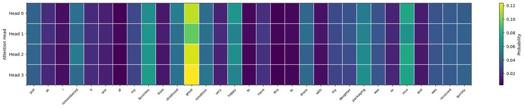

```python
s = "Just as I remembered it, one of my favorites from childhood! Great condition, very happy to have this to share with my daughter. Packaging was so nice and was received quickly."
pred, tokens, attn = get_label_and_weights(s)
print(f"Prediction: {'Positive' if pred == 1 else 'Negative'}")
visualize_attention(tokens, attn)
```

```
Prediction: 0.0026, Label: 0
Attention shape: torch.Size([1, 4, 39])
Prediction: Negative
```

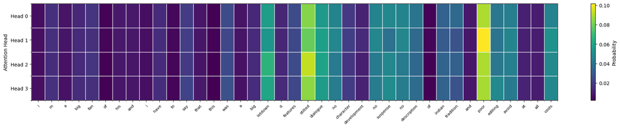

```python
s = """
I'm a big fan of his, and I have to say that this was a BIG letdown. It features: Stilted dialogue, no character development, no suspense, no description of Indian tradition and poor editing.\n\nAvoid at all costs.
"""
pred, tokens, attn = get_label_and_weights(s)
print(f"Prediction: {'Positive' if pred == 1 else 'Negative'}")
visualize_attention(tokens, attn)
```

#### **Initial Attention Visualization Insights**

The visualizations of the positive and negative examples reveal striking differences in attention allocation. In the positive review about a childhood favorite, all four attention heads heavily focus on emotionally-charged words like "favorites," "great," and "happy," with attention weights peaking at these sentiment signifiers. Conversely, in the negative review about the "BIG letdown," the attention mechanism zeroes in on "letdown," "poor," and "avoid," while also giving weight to negation words like "no" that appear repeatedly. This contrast demonstrates the model's ability to identify sentiment-carrying terms regardless of context, with each attention head showing similar but not identical focus patterns, suggesting they've learned complementary aspects of sentiment expression.

```
Positive Heatmap 1
Text: Rollicking tales of what once was, and timeless examples of who we should still be. ...
Prediction: 0.9877, Label: 1
Attention shape: torch.Size([1, 4, 15])
Prediction: Positive
```

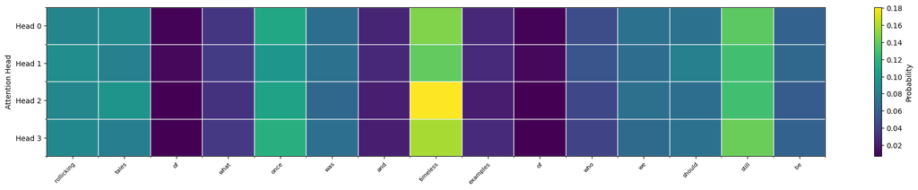

```
Positive Heatmap 2
Text: I just got this book a few days ago and I love it. I have been sewing for years, but I still like to...
Prediction: 0.9753, Label: 1
Attention shape: torch.Size([1, 4, 73])
Prediction: Positive
```

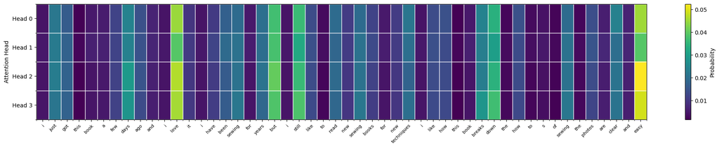

```
Negative Heatmap 1
Text: Some good tech. info. but the books drags and drags and drags. Not well written. Could have provided...
Prediction: 0.1685, Label: 0
Attention shape: torch.Size([1, 4, 24])
Prediction: Negative
```

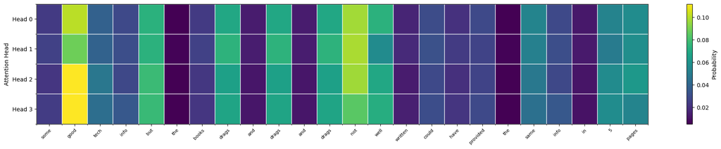

```
Negative Heatmap 2
Text: Was not into it I guess. Characters could have been more. Some characters shouldn't have been at all...
Prediction: 0.0050, Label: 0
Attention shape: torch.Size([1, 4, 30])
Prediction: Negative
```

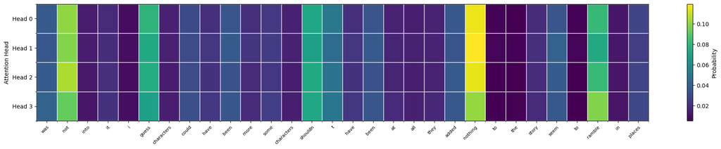

```python
# Sample positive examples from dev set
pos_example1 = sent_dev_df[sent_dev_df["label"] == 1].iloc[10]["text"]
pos_example2 = sent_dev_df[sent_dev_df["label"] == 1].iloc[15]["text"]

# Sample negative examples from dev set
neg_example1 = sent_dev_df[sent_dev_df["label"] == 0].iloc[20]["text"]
neg_example2 = sent_dev_df[sent_dev_df["label"] == 0].iloc[30]["text"]

# Visualize the examples
for i, (text, label_name) in enumerate(
    [
        (pos_example1, "Positive Heatmap 1"),
        (pos_example2, "Positive Heatmap 2"),
        (neg_example1, "Negative Heatmap 1"),
        (neg_example2, "Negative Heatmap 2"),
    ]
):
    print(f"\n{label_name}")
    print(f"Text: {text[:100]}..." if len(text) > 100 else f"Text: {text}")
    pred, tokens, attn = get_label_and_weights(text)
    print(f"Prediction: {'Positive' if pred == 1 else 'Negative'}")
    visualize_attention(tokens, attn)
```

```
Tricky Example 1:
Text: This book was absolutely terrible but I couldn't put it down.
Prediction: 0.0221, Label: 0
Attention shape: torch.Size([1, 4, 12])
Prediction: 0.0000, Label: 0
Prediction: Negative
```

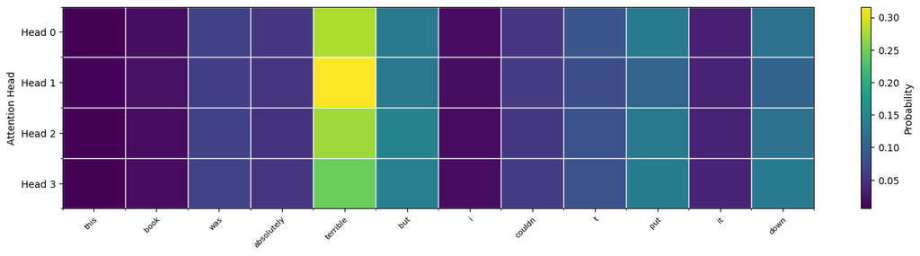

```
Tricky Example 2:
Text: Not the worst product I've ever used, which isn't saying much.
Prediction: 0.0000, Label: 0
Attention shape: torch.Size([1, 4, 13])
Prediction: 0.0000, Label: 0
Prediction: Negative
```

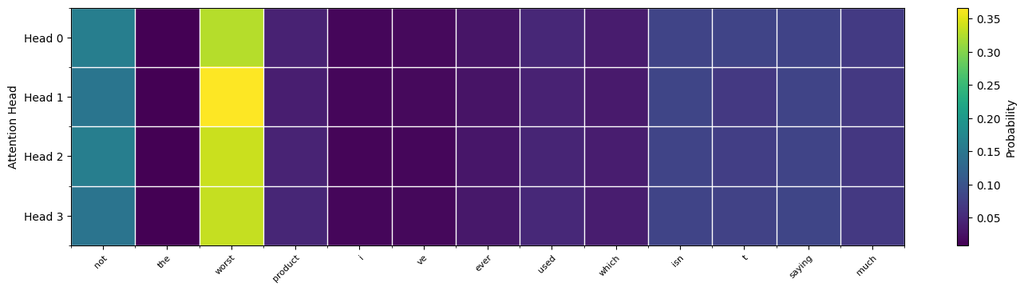

```
Tricky Example 3:
Text: While I hated every moment reading it, I have to admit it was well-written.
Prediction: 0.7712, Label: 1
Attention shape: torch.Size([1, 4, 15])
Prediction: 1.0000, Label: 1
Prediction: Positive
```

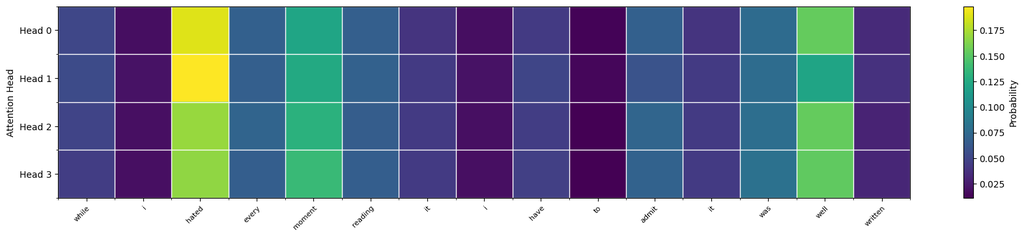

```
Tricky Example 4:
Text: The story was predictable and boring, but somehow it kept me engaged until the end.
Prediction: 0.0096, Label: 0
Attention shape: torch.Size([1, 4, 15])
Prediction: 0.0000, Label: 0
Prediction: Negative
```

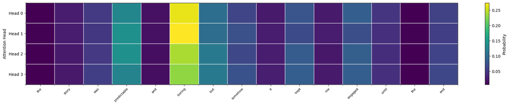

```
Tricky Example 5:
Text: I wouldn't recommend this to my friends, but I don't regret buying it.
Prediction: 0.1061, Label: 0
Attention shape: torch.Size([1, 4, 15])
Prediction: 0.0000, Label: 0
Prediction: Negative
```

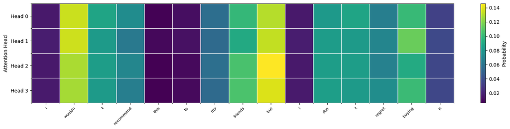

```python
# Trying to fool the classifier with ambiguous or mixed sentiment
tricky_examples = [
    "This book was absolutely terrible but I couldn't put it down.",
    "Not the worst product I've ever used, which isn't saying much.",
    "While I hated every moment reading it, I have to admit it was well-written.",
    "The story was predictable and boring, but somehow it kept me engaged until the end.",
    "I wouldn't recommend this to my friends, but I don't regret buying it.",
]

for i, text in enumerate(tricky_examples):
    print(f"\nTricky Example {i + 1}:")
    print(f"Text: {text}")
    pred, tokens, attn = get_label_and_weights(text)
    print(f"Prediction: {pred:.4f}, Label: {1 if pred > 0.5 else 0}")
    print(f"Prediction: {'Positive' if pred > 0.5 else 'Negative'}")
    visualize_attention(tokens, attn)
```